# Parameter Sensitivity Analysis for MFRL Model

Ismail Guennouni

2025-02-27

# 1. Introduction

This document implements a systematic parameter sensitivity analysis for the Model-Free Reinforcement Learning (MFRL) model applied to trust game data in R. The trust game is a widely used experimental paradigm in behavioral economics and psychology that measures trust and trustworthiness between individuals. In a typical trust game, one player (the investor) decides how much of an endowment to send to another player (the trustee). The amount sent is multiplied (usually tripled), and the trustee then decides how much to return to the investor.

The MFRL model attempts to capture how participants (N=183, role fo trustee over two 25 round games) learn from their experiences in the trust game using reinforcement learning principles combined with social preferences. The goal of our sensitivity analysis is to understand which parameters are identifiable from the data and which might need to be fixed at literature values.

We employ multiple complementary approaches to thoroughly assess parameter sensitivity:

- **Parameter Slice Analysis:**
  - We systematically vary each parameter individually while holding others constant at their optimal values.
  - This creates one-dimensional “slices” through the parameter space.
  - We calculate sensitivity as the average gradient of the negative log-likelihood (NLL) along each slice.
  - This approach quantifies how quickly model fit deteriorates as each parameter deviates from its optimal value.
- **Grid Search Analysis:**
  - We evaluate model fit across a multidimensional grid spanning the parameter space.
  - This approach reveals parameter interactions and regions of good fit.
  - It helps identify parameter trade-offs and potential identifiability issues when multiple parameter combinations yield similar model fits.
- **Fisher Information Matrix (FIM) Analysis:**
  - This theoretical approach calculates the curvature of the likelihood surface at the optimal parameter values.
  - The FIM provides:
    - Parameter precision estimates (diagonal elements).
    - Parameter interdependencies (off-diagonal elements).
    - Condition numbers that quantify overall identifiability.
  - While mathematically elegant, this approach can face numerical challenges with complex models.
- **Visualization and Statistical Summaries:**
  - We visualize sensitivity distributions across participants using boxplots and heatmaps to identify consistent patterns of parameter importance.
  - We also compute average NLL profiles to show how model fit changes as parameters vary from their optimal values.

Together, these approaches provide multiple perspectives on parameter identifiability, helping determine:

- Which parameters strongly affect model predictions.
- Which have flat likelihood surfaces and are difficult to identify.
- Where in parameter space sensitivity issues are most problematic.

This analysis examines how sensitive the model fit is to changes in each parameter across different participants. The analysis uses a reinforcement learning model with social preference components, specifically examining four key parameters:

1. **alpha**: Learning rate parameter that controls how quickly agents update their expectations based on new information. Higher values mean faster learning from recent outcomes.
2. **temp**: Temperature parameter for the softmax choice function, controlling choice stochasticity or exploration. Higher values indicate more random choices.
3. **envy**: Parameter related to disadvantageous inequality aversion (disutility from others getting more than oneself). Higher values indicate stronger aversion to receiving less than the partner.
4. **guilt**: Parameter related to advantageous inequality aversion (disutility from getting more than others). Higher values indicate stronger aversion to receiving more than the partner.

# 2. MFRL model

## Model-Free Reinforcement Learning (Q-Learning) with Fehr-Schmidt Utility

This section outlines the mathematical equations for a model-free reinforcement learning agent using Q-learning, incorporating the Fehr-Schmidt utility function to account for social preferences.

**1. Standard Q-Learning Update:**

The traditional Q-learning update rule is:

`Q(s, a) ← Q(s, a) + α [r + γ max_a' Q(s', a') - Q(s, a)]`

where:

- `Q(s, a)`: Q-value of taking action `a` in state `s`.
- `α`: Learning rate (0 < α ≤ 1).
- `r`: Immediate reward received after taking action `a` in state `s`.
- `γ`: Discount factor (0 ≤ γ < 1).
- `s'`: Next state.
- `max_a' Q(s', a')`: Maximum Q-value of any action in the next state `s'`.

**2. Fehr-Schmidt Utility Function:**

The Fehr-Schmidt utility function models inequity aversion. For two players, `i` and `j`, the utility of player `i` is:

`U_i(x_i, x_j) = x_i - α_i max{x_j - x_i, 0} - β_i max{x_i - x_j, 0}`

where:

- `x_i`: Payoff of player `i`.
- `x_j`: Payoff of player `j`.
- `α_i`: Envy parameter (measures aversion to being worse off than player `j`).
- `β_i`: Guilt parameter (measures aversion to being better off than player `j`).
- `α_i ≥ 0`, `β_i ≥ 0`, and `β_i ≤ α_i`.

**3. Modified Q-Learning Update with Fehr-Schmidt Utility:**

We modify the reward `r` in the Q-learning update to incorporate the Fehr-Schmidt utility. Assuming the agent’s reward is `x_i` and the other player’s is `x_j`, the modified reward `r'` is:

`r' = x_i - α_i max{x_j - x_i, 0} - β_i max{x_i - x_j, 0}`

The Q-learning update then becomes:

`Q(s, a) ← Q(s, a) + α [r' + γ max_a' Q(s', a') - Q(s, a)]`

or

`Q(s, a) ← Q(s, a) + α [x_i - α_i max{x_j - x_i, 0} - β_i max{x_i - x_j, 0} + γ max_a' Q(s', a') - Q(s, a)]`

**4. Softmax Action Selection with Temperature:**

To introduce exploration, we use a softmax action selection policy:

`P(a|s) = exp(Q(s, a) / τ) / Σ_a' exp(Q(s, a') / τ)`

where:

- `P(a|s)`: Probability of choosing action `a` in state `s`.
- `τ`: Temperature parameter (τ > 0). Higher temperature leads to more exploration.

**Summary of Parameters:**

- `α`: Learning rate.
- `γ`: Discount factor.
- `α_i`: Envy parameter.
- `β_i`: Guilt parameter.
- `τ`: Temperature parameter.

This section loads necessary R libraries for computation, parallel processing, numerical methods, and visualization. It also defines several key helper functions that are used in the MFRL model:

- **get_investment_bin**: Maps continuous investment values to discrete states (1-3) for the Q-learning model, allowing the model to categorize investment amounts into low, medium, and high ranges.
- **get_return_bin**: Maps continuous return proportions to discrete actions (1-6) for the Q-learning model, creating six equal-sized bins for the possible return proportions from 0 to 1.
- **calculate_fs_utility**: Implements the Fehr-Schmidt inequality aversion utility function, which adjusts the utility based on payoff differences between self and other, accounting for both disadvantageous inequality (envy) and advantageous inequality (guilt).

The model fitting algorithm operates as follows:

1. **Input:** Accepts participant behavioral data and model parameter values.
2. **Initialization:** Sets initial Q-values (expected utilities) for all state-action pairs.
3. **Trial Loop:** Iterates through each trial:
   - Calculates action probabilities using the softmax function.
   - Updates Q-values based on temporal difference (TD) learning.
4. **Likelihood Calculation:** Computes the negative log-likelihood (NLL) of the participant’s observed choices.
5. **Optional Output:** Returns internal model variables for diagnostic purposes, if requested.

This model captures both the learning process (via Q-learning) and social preferences (via the Fehr-Schmidt utility function) in trust game behavior.

# 3. Grid-Based Parameter Sensitivity Analysis Function

The function `calculate_grid_sensitivity` implements a comprehensive exploration of model behavior across the parameter space. It works by:

1. Creating a grid of parameter combinations by taking all possible combinations of specified parameter values
2. Evaluating the model’s negative log-likelihood (NLL) for each parameter combination
3. Identifying which combinations produce the best and worst model fits

This approach is particularly valuable for detecting complex interactions between parameters, identifying regions of parameter space where the model performs well or poorly and revealing parameter correlations that might affect identifiability

The function supports parallel processing to handle the computational demands of evaluating many parameter combinations efficiently. For each evaluated point in parameter space, it captures both the NLL value and any potential errors, ensuring robustness even when some parameter combinations might cause numerical issues.

The output includes the full results data frame, the minimum NLL found, and the corresponding best parameter set, providing a comprehensive view of how the parameter space affects model fit.

# 4. Parameter Slice Analysis Function

The function `calculate_parameter_slices` takes a more targeted approach to sensitivity analysis by:

1. Holding all parameters constant at their “center” (typically the best-fitting) values
2. Varying one parameter at a time across a specified range
3. Computing the NLL at each point to create “slices” through the likelihood surface

This one-at-a-time approach allows for precise quantification of each parameter’s individual contribution to model fit while controlling for the effects of other parameters. The function generates parameter ranges either from global bounds or by creating reasonable ranges around the center values, adapting to the characteristics of each parameter (e.g., learning rates constrained between 0 and 1).

For each parameter slice, the function calculates: - The raw NLL values - The “delta NLL” (difference from minimum NLL in the slice) - A sensitivity metric based on the average absolute gradient of the delta NLL curve

This gradient-based sensitivity metric quantifies how quickly the model fit deteriorates as each parameter deviates from its optimal value. Higher sensitivity values indicate parameters that strongly influence model fit and are therefore more reliably identifiable from the data.

# 5. FIM-Based Parameter Sensitivity Analysis

The function `calculate_fisher_information` implements a more mathematically rigorous approach to parameter identifiability using the Fisher Information Matrix (FIM). The FIM provides a formal measure of how much information the data contains about each parameter and how parameters might be correlated.

The function works by:

1. Computing the Hessian matrix (second derivatives) of the negative log-likelihood with respect to all parameters
2. Taking the negative of this Hessian to form the Fisher Information Matrix
3. Extracting various diagnostics from this matrix

Key outputs include:

- **Parameter precision** (diagonal elements): Higher values indicate more precise parameter estimates
- **Condition number**: The ratio of largest to smallest eigenvalues, with high values (>100) indicating potential identifiability issues
- **Standardized FIM**: A correlation-like matrix showing parameter interdependencies

The function uses numerical differentiation methods from the numDeriv package for stability, with a fallback to manual second derivative calculation if needed. It also handles potential numerical issues like non-positive definite matrices, making it robust for real-world data analysis.

This FIM-based approach complements the other sensitivity methods by providing a theoretical foundation for parameter identifiability based on information theory.

# 6. Comprehensive Participant Sensitivity Analysis

The function `analyze_participant_sensitivity` performs a multi-method sensitivity analysis for a single participant’s data. It integrates the three previous approaches (FIM, parameter slices, and grid search) to provide a comprehensive view of parameter identifiability for that individual.

The function begins with diagnostic tests to ensure the model works with the provided parameters, reporting any issues encountered. It then sequentially applies:

1. Fisher Information Matrix calculation at the center parameters
2. Parameter slice analysis across specified ranges
3. Optional grid-based sensitivity analysis if a parameter grid is provided

This multi-pronged approach is valuable because each method has different strengths:

- FIM provides theoretical identifiability and parameter correlations
- Parameter slices give intuitive sensitivity measures for each parameter
- Grid search reveals complex interactions between parameters

The function handles errors gracefully at each stage, allowing the analysis to continue even if one method fails. It returns a comprehensive results structure that includes all successful analyses along with participant metadata, enabling both detailed individual assessment and integration into population-level analyses.

# 7. Parallelized Multi-Participant Analysis

The function `analyze_population_sensitivity` extends the comprehensive sensitivity analysis to multiple participants, leveraging parallel processing for efficiency. This is crucial for studies with many participants, as sensitivity analyses are computationally intensive.

# 8. Population-Level Summary Function

The function `summarize_population_sensitivity` aggregates sensitivity results across participants to identify general patterns of parameter identifiability. This population-level view is essential for drawing broader conclusions about which parameters are consistently identifiable versus those that vary in importance across individuals.

# 9. Visualization Functions

This section implements three key visualization functions that translate the technical sensitivity metrics into intuitive graphical representations:

## Plot_sensitivity_boxplots

Creates boxplots showing the distribution of sensitivity values for each parameter across participants. Higher Median Sensitivity: A parameter with a higher median sensitivity is more influential in determining the model’s NLL. It means that small deviations from the optimal value lead to large increases in NLL. Low Sensitivity: If the boxplot shows low sensitivity values (with little variability), it suggests that changes in that parameter have minimal impact on the NLL. Such parameters may be candidates for fixing at a literature value rather than estimating from the data. The implementation includes: - Diagnostic checks of the sensitivity matrix - Manual creation of a plotting data frame - Application of a logarithmic scale to handle the wide range of sensitivity values - Addition of individual data points to show the full distribution

## plot_sensitivity_heatmap

Generates a heatmap visualization of parameter sensitivity across all participants, with: - Optional normalization of sensitivity values by parameter - Safety checks to handle missing or invalid data - Color coding using the viridis palette for accessibility - Proper labeling and theme customization

## plot_average_nll_profiles

Creates line plots showing how the NLL changes as each parameter deviates from its optimal value, featuring: - Extensive diagnostic checks to identify and report issues - Combination of slice data across participants - Normalization of parameter values to enable cross-parameter comparison - Calculation of mean and standard error for delta NLL values - Ribbon plots showing uncertainty around the mean profiles

## plot_grid_results

function visualizes the results of grid searches, creating heatmaps for each parameter pair to show how combinations of parameters affect model fit.

## Visualise fim results

function to plot results of the Fisher Information Matrix analysis

These visualizations complement each other, providing multiple perspectives on parameter sensitivity from distribution summaries to detailed interaction patterns.

### Condition Number

The condition number is a measure of how “well-behaved” the parameter estimation problem is. It’s calculated as the ratio of the largest eigenvalue to the smallest eigenvalue of the Fisher Information Matrix.

### Eigenvalue Spectrum

The eigenvalue spectrum refers to the set of all eigenvalues of the Fisher Information Matrix, typically arranged in descending order.

# 10. Complete Analysis Function

The function `run_sensitivity_analysis` orchestrates the entire sensitivity analysis pipeline, providing a single entry point for the complete workflow. It coordinates:

1. Setting up the analysis environment, including timing the process
2. Defining parameter grids and ranges for comprehensive exploration
3. Running the population-level sensitivity analysis
4. Generating all visualizations from the results
5. Packaging everything into a structured output

The function includes sensible defaults for parameter ranges based on theoretical constraints and common values from literature: - alpha (learning rate): 0.01 to 0.99 - temp (temperature): 0.1 to 10 - envy: 0 to 6 - guilt: 0 to 5

# 11. Results

The results section presents the findings from applying our sensitivity analysis framework to the full dataset of 183 participants. The function pipeline is as follows:

1. `run_sensitivity_analysis` takes the complete dataset with all participants
2. `analyze_population_sensitivity` automatically splits this data by participant ID
3. Each participant’s data is analyzed individually (in parallel across our cores)
4. `summarize_population_sensitivity` aggregates results across all participants
5. The visualization functions show the distribution of sensitivity across our entire population

The analysis calculates a comprehensive set of sensitivity metrics and visualizations, including boxplots of parameter sensitivity, heatmaps showing sensitivity across participants, average NLL profiles, and grid search results revealing parameter interactions.

**Mean Parameter Sensitivity:**

- temp (temperature): 334.002
- guilt: 219.94
- alpha (learning rate): 71.508
- envy: 7.768

### Boxplot Visualization

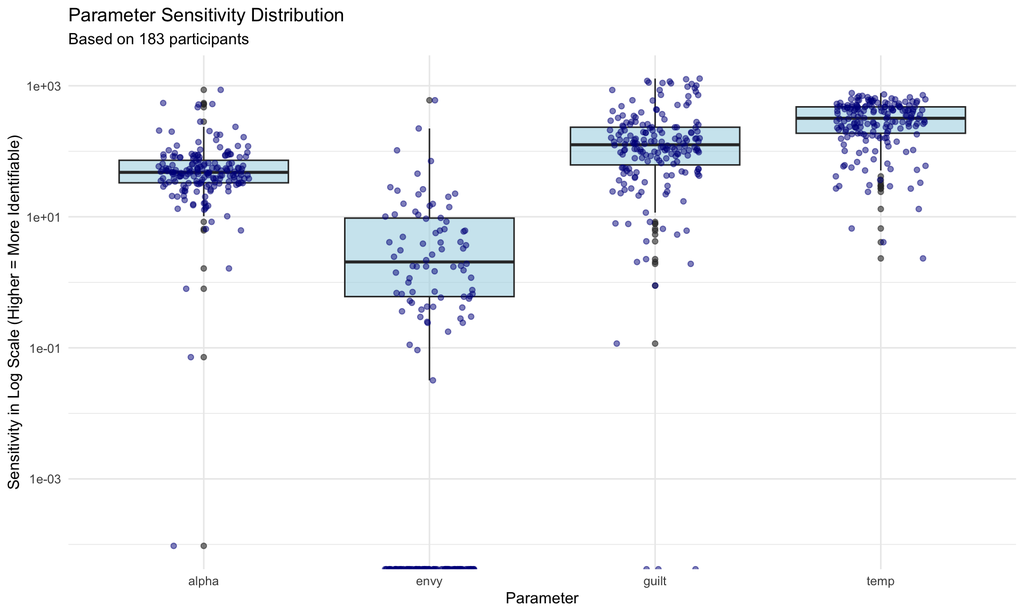

This boxplot displays the distribution of sensitivity values for each parameter across all 183 participants.

The boxplot illustrates the distribution of parameter sensitivity across participants.

**Key Findings:**

- **Parameter Hierarchy:** temp > guilt > alpha > envy, indicating varying levels of influence on model fit.
- **Distribution:** Right-skewed distributions across all parameters, spanning multiple orders of magnitude.
- **Individual Variation:** Significant spread in sensitivity values, highlighting individual differences in parameter influence.
- **Implications:** temp and guilt are crucial for model fit; envy may be less critical.

### Heatmap Visualization

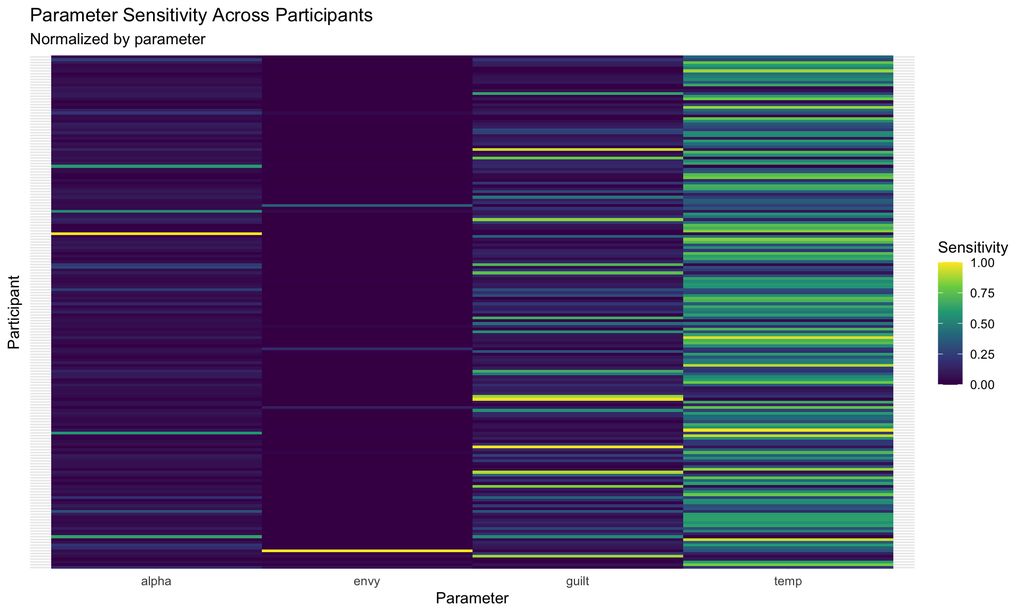

The heatmap displays participant-level parameter sensitivity.

### Average NLL Profiles

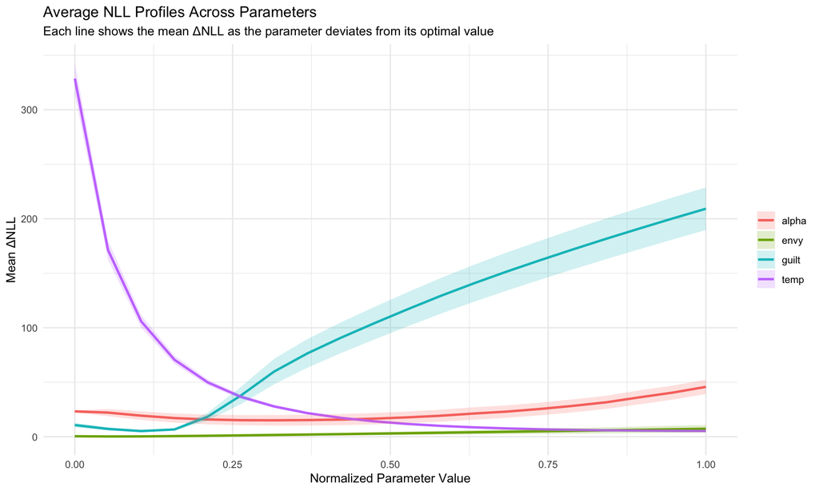

This plot illustrates how the model fit (measured by negative log-likelihood) changes as each parameter is varied.

**Key Findings:**

- **temp:** High sensitivity at low values, crucial for accurate estimation.
- **guilt:** High sensitivity at high values, overestimation worsens fit.
- **alpha:** Moderate sensitivity, optimal values in the mid-range.
- **envy:** Minimal sensitivity, suggesting potential for fixing this parameter.
- **Practical Recommendations:** Careful estimation of temp and guilt; flexibility for alpha; potential exclusion of envy.

### FIM results

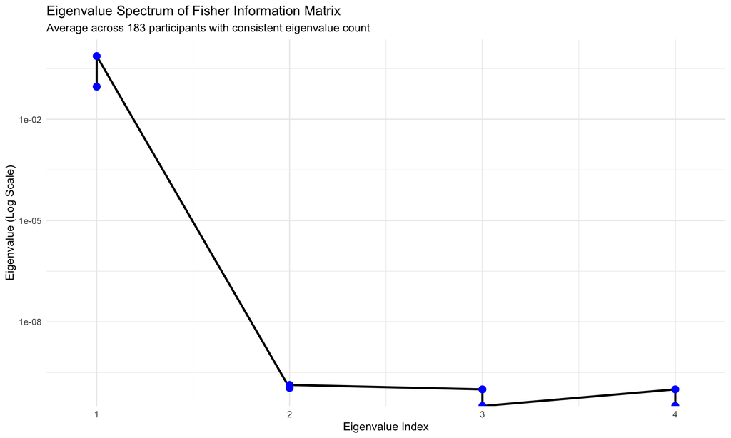

### Grid Search Results

Grid search heatmaps visualize parameter interaction effects on model fit.

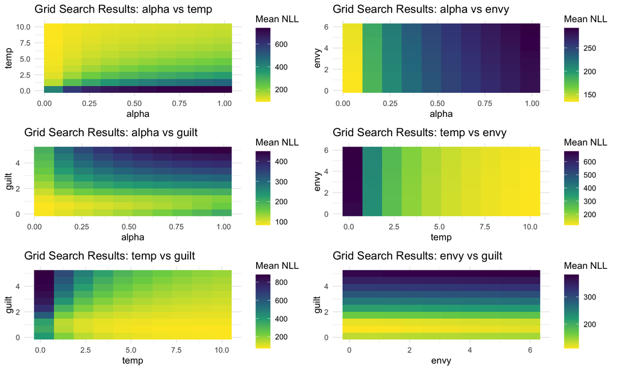

### Overall Implications

The consistent findings across analyses highlight the importance of temp and guilt, while suggesting envy’s reduced role. This information aids parameter estimation and model simplification.

# Appendix:

## Parameter Normalization Process

This outlines how parameter normalization is performed in the sensitivity analysis.

**1. Sensitivity Analysis for Each Participant and Parameter:**

- For every participant and each parameter (e.g., envy, guilt, temperature), the analysis begins.
- It starts with the participant’s best-fitting parameter value (e.g., envy = 1.5).
- A range of parameter values around this optimum is tested (e.g., envy = 0.5, 1.0, 1.5, 2.0, 2.5).
- For each tested value, the change in model fit (Negative Log-Likelihood, NLL) is calculated.

**2. Normalization per Participant:**

- The normalization is done independently for each participant.
- For each parameter, the minimum and maximum tested parameter values are identified.
- This range is then rescaled to a 0-1 scale, where:
  - 0 represents the minimum tested value for that participant and parameter.
  - 1 represents the maximum tested value for that participant and parameter.
- This normalization allows for averaging sensitivity curves across participants, even if they have different:
  - Optimal parameter values.
  - Testing ranges.

**3. Concrete Example (Envy Parameter):**

- **Participant 1:** Tested values 0.5-2.5 are normalized to 0-1.
- **Participant 2:** Tested values 1.0-3.0 are normalized to 0-1.
- **Participant 3:** Tested values 0.2-1.2 are normalized to 0-1.

**4. Interpretation of Results:**

- The resulting plot displays the average sensitivity of the model fit across participants along the normalized 0-1 range.
- A high ∆NLL (change in NLL) at x=0.2 indicates: “When the parameter is 20% of the way from its minimum to maximum tested value, the model fit is typically this much worse than at the optimum.”